# Modeling quality of suggestions

Ankit Gyawali

4/30/2020

## Section 1: Introduction

The goal of this project is to identify various relavant factors that could be used to classify “good” & “bad” suggestions provided on a human resource company. We compare the performance of various model to identify the best algorithm for this prediction task and evaluate if the model can be deployed on production. Finally, we discus and provide recommendations as to if any other attributes that might be more valuable for future classification task.

We group the report as follows and present our findings on last section:

- Introduction
- Data Cleanup and Transformation
- Data Shape Exploration
- Data Analysis/Modelling
  - Predictor selection - predictors that can classify suggestion
  - Modelling & Selection based on classification performance/CV
- Conclusion

#### Libraries import

```r
library(dplyr) # Data Manip
library(ggplot2) # Plotting
library(gridExtra)
library(corrplot)
library(plotmo)
library(pROC)
library(randomForest) # Modelling
library(glmnet)
library(caret)
library(klaR)
library(MASS)
library(leaps)
library(rpart)
library(partykit)
library(prettydoc) # Theming
library(knitr)
```

## Section 2: Data Cleanup and Transformation

First we load our data.

*Note: For localhost: https://drive.google.com/open?id=1k_0HMD99lPkqOOUfQcFSq5c6lUVmd6eL*

```r
## Mirror #1
hrdata <- read.csv("http://www.andrew.cmu.edu/user/agyawali/suggestions.csv", header=TRUE)

# Mirror #2
# hrdata <- read.csv("https://gist.githubusercontent.com/ankitgyawali/608b857d160b3426225b65883bf13b72/raw/1ea4738d81b4465178b29e1f41b00c666eb8fc30/suggestions.csv", header=TRUE)

# Localhost
# hrdata <- read.csv("suggestions.csv", header=TRUE)
```

Renaming columns with snake case:

```r
column.names <-  c("recommended", "suggestion_id","responses","views","upvotes", "downvotes","author_id", "author_profile_age", "author_total_posts", "author_posts_per_day")
colnames(hrdata) <- column.names
column.names
```

```
##  [1] "recommended"          "suggestion_id"        "responses"            "views"                "upvotes"              "downvotes"            "author_id"            "author_profile_age"
##  [9] "author_total_posts"   "author_posts_per_day"
```

From the above we can see some columns that could have interactions that we might want to use later on.

- upvotes & downvotes
- response & views
- profile age & total posts

The third interaction already present on our data set as author_posts_per_day, we will capture the first two interactions as follows. *NA & Inifinite values are replaced by 0 or 1 appropriately when calculating these interactions.*

```r
## Popularity
hrdata$popularity <- 1- hrdata$downvotes/hrdata$upvotes
hrdata$popularity[is.na(hrdata$popularity)] <- 0
hrdata$popularity[is.infinite(hrdata$popularity)] <- 1

## Response per view
hrdata$responsiveness <- hrdata$responses/hrdata$views
hrdata$responsiveness[is.na(hrdata$responsiveness)] <- 0
```

Converting the “recommended” column of interest as factor:

```r
hrdata$recommended <- as.factor(hrdata$recommended)
```

We divide our data into training and test set with approximately 90% & 10% of total samples we have respectively. We also clone the training and testing set into a different variable before dropping out irrelevant primary keys for our analysis like author_id & suggestion_id.

```r
# set.seed(222) # TODO: Disable this
test <- sample(1:nrow(hrdata), 1600)

hrdata.train <- hrdata[-test,]
hrdata.test <- hrdata[test,]

hrdata.train.all <- hrdata[-test,]
hrdata.test.all <- hrdata[test,]

hrdata.train <- subset(hrdata.train, select = -c(author_id, suggestion_id))
hrdata.test <- subset(hrdata.test, select = -c(author_id, suggestion_id))
```

## Section 3: Data Shape Exploration

Following outputs a basic statistic table for our data set grouped by the two kinds of recommended posts.

```r
summary.var.names <- c("responses", "views", "upvotes", "downvotes", "author_profile_age","author_total_posts", "author_posts_per_day")

hrdata.rec.summary <- summary(subset(hrdata, recommended == 1)[,summary.var.names])
hrdata.nrec.summary <- summary(subset(hrdata, recommended == 0)[,summary.var.names])

kable(hrdata.rec.summary, padding= 3 ,format = "html", caption  = "**Recommended posts**")
```

**Recommended posts**

|  | responses | views | upvotes | downvotes | author_profile_age | author_total_posts | author_posts_per_day |
| --- | --- | --- | --- | --- | --- | --- | --- |
|  | Min. : 0.00 | Min. : 0 | Min. : 0.0 | Min. : 0.000 | Min. : 231 | Min. : 10 | Min. :0.00 |
|  | 1st Qu.: 34.00 | 1st Qu.: 814 | 1st Qu.: 45.0 | 1st Qu.: 1.000 | 1st Qu.:1011 | 1st Qu.: 711 | 1st Qu.:0.50 |
|  | Median : 48.00 | Median : 1468 | Median : 69.5 | Median : 4.000 | Median :1214 | Median :1330 | Median :1.20 |
|  | Mean : 60.51 | Mean : 3076 | Mean : 103.9 | Mean : 7.641 | Mean :1173 | Mean :2121 | Mean :1.88 |
|  | 3rd Qu.: 69.00 | 3rd Qu.: 2834 | 3rd Qu.: 115.0 | 3rd Qu.: 10.000 | 3rd Qu.:1341 | 3rd Qu.:2834 | 3rd Qu.:2.90 |
|  | Max. :959.00 | Max. :63243 | Max. :2607.0 | Max. :199.000 | Max. :1623 | Max. :6920 | Max. :7.10 |

```r
kable(hrdata.nrec.summary, padding= 3 ,format = "html", caption  = "**Not recommended posts**")
```

**Not recommended posts**

|  | responses | views | upvotes | downvotes | author_profile_age | author_total_posts | author_posts_per_day |
| --- | --- | --- | --- | --- | --- | --- | --- |
|  | Min. : 0.00 | Min. : 0 | Min. : 0.00 | Min. : 0.000 | Min. : 4 | Min. : 1.0 | Min. : 0.0000 |
|  | 1st Qu.: 3.00 | 1st Qu.: 92 | 1st Qu.: 0.00 | 1st Qu.: 0.000 | 1st Qu.: 773 | 1st Qu.: 54.0 | 1st Qu.: 0.1000 |
|  | Median : 7.00 | Median : 173 | Median : 2.00 | Median : 1.000 | Median :1027 | Median : 275.0 | Median : 0.3000 |
|  | Mean : 13.63 | Mean : 430 | Mean : 11.65 | Mean : 3.619 | Mean :1017 | Mean : 697.8 | Mean : 0.6857 |
|  | 3rd Qu.: 15.00 | 3rd Qu.: 365 | 3rd Qu.: 7.00 | 3rd Qu.: 5.000 | 3rd Qu.:1291 | 3rd Qu.: 834.0 | 3rd Qu.: 0.9000 |
|  | Max. :487.00 | Max. :30072 | Max. :1149.00 | Max. :201.000 | Max. :1624 | Max. :9992.0 | Max. :20.1000 |

We see that consistently- response, views & upvotes are a lot higher on recommended posts then on un-recommended posts.

Simialarly, the mean & median seem to suggest that the author profile age does not matter, however their frequency of posting tends higher on recommended posts - which implies authors whose posts are more recommended do tend to post more frequently.

We will now further visualize these data points as boxplots, removing the first 10% & bottom 10% of outliers so that the boxplot scale is zoomed in.

### Botplots of various variables

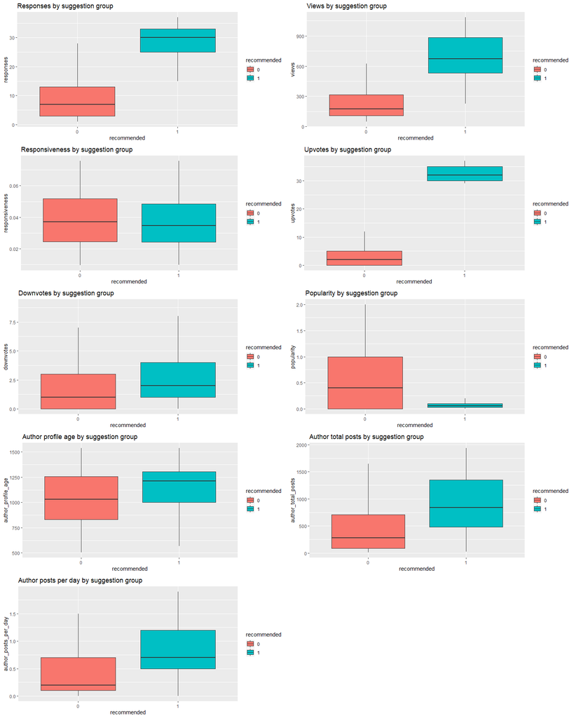

```r
bpxplot.responses <- ggplot(hrdata, aes(recommended, responses,  fill=recommended), na.rm = T) + geom_boxplot(na.rm = T, outlier.shape = NA) + ggtitle("Responses by suggestion group") + scale_y_continuous(limits = quantile(hrdata$responses, c(0.1, 0.9)))
bpxplot.views <- ggplot(hrdata, aes(recommended, views,  fill=recommended), na.rm = T) + geom_boxplot(na.rm = T, outlier.shape = NA) + ggtitle("Views by suggestion group") + scale_y_continuous(limits = quantile(hrdata$views, c(0.1, 0.9)))
boxplot.responsiveness <- ggplot(hrdata, aes(recommended, responsiveness,  fill=recommended), na.rm = T) + geom_boxplot(na.rm = T, outlier.shape = NA) + ggtitle("Responsiveness by suggestion group") + scale_y_continuous(limits = quantile(hrdata$responsiveness, c(0.1, 0.9)))

boxplot.upvotes <- ggplot(hrdata, aes(recommended, upvotes,  fill=recommended), na.rm = T) + geom_boxplot(na.rm = T, outlier.shape = NA) + ggtitle("Upvotes by suggestion group") + scale_y_continuous(limits = quantile(hrdata$upvotes, c(0.1, 0.9)))
boxplot.downvotes <- ggplot(hrdata, aes(recommended, downvotes,  fill=recommended), na.rm = T) + geom_boxplot(na.rm = T, outlier.shape = NA) + ggtitle("Downvotes by suggestion group") + scale_y_continuous(limits = quantile(hrdata$downvotes, c(0.1, 0.9)))
boxplot.popularity <- ggplot(hrdata, aes(recommended, popularity,  fill=recommended), na.rm = T) + geom_boxplot(na.rm = T, outlier.shape = NA) + ggtitle("Popularity by suggestion group") + scale_y_continuous(limits = quantile(hrdata$popularity, c(0.1, 0.9)))

boxplot.author_profile_age <- ggplot(hrdata, aes(recommended, author_profile_age,  fill=recommended), na.rm = T) + geom_boxplot(na.rm = T, outlier.shape = NA) + ggtitle("Author profile age by suggestion group") + scale_y_continuous(limits = quantile(hrdata$author_profile_age, c(0.1, 0.9)))
boxplot.author_total_posts <- ggplot(hrdata, aes(recommended, author_total_posts,  fill=recommended), na.rm = T) + geom_boxplot(na.rm = T, outlier.shape = NA) + ggtitle("Author total posts by suggestion group") + scale_y_continuous(limits = quantile(hrdata$author_total_posts, c(0.1, 0.9)))
boxplot.author_posts_per_day <-  ggplot(hrdata, aes(recommended, author_posts_per_day,  fill=recommended), na.rm = T) + geom_boxplot(na.rm = T, outlier.shape = NA) + ggtitle("Author posts per day by suggestion group") + scale_y_continuous(limits = quantile(hrdata$author_posts_per_day, c(0.1, 0.9)))

grid.arrange(bpxplot.responses, bpxplot.views, boxplot.responsiveness, boxplot.upvotes, boxplot.downvotes, boxplot.popularity, boxplot.author_profile_age, boxplot.author_total_posts,  boxplot.author_posts_per_day,  ncol=2)
```

These boxplots confirm the picture we had looking at the two kable tables earlier and the trends we pointed. The mean points seems to be closes on profile age as previously mentioned suggesting age of profile might not be as big of a factor when it comes to quality of posts.

### Co-relation matrix

We can expect the interaction terms to be somewhat co-related. Modelling the real world, we can also expect that maybe the upvotes & downvotes could potentially be co-related. We present a co-relation matrix of our main predictors below.

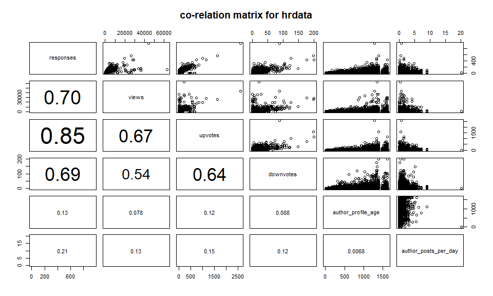

```r
panel.cor <- function(x, y, digits = 2, prefix = "", cex.cor, ...)
{
    usr <- par("usr"); on.exit(par(usr))
    par(usr = c(0, 1, 0, 1))
    r <- abs(cor(x, y))
    txt <- format(c(r, 0.123456789), digits = digits)[1]
    txt <- paste0(prefix, txt)
    if(missing(cex.cor)) cex.cor <- 0.8/strwidth(txt)
    text(0.5, 0.5, txt, cex = pmax(1, cex.cor * r))
}

pair.var.names <- c("responses", "views", "upvotes", "downvotes", "author_profile_age", "author_posts_per_day")
pairs(hrdata[,pair.var.names], lower.panel = panel.cor, main = "co-relation matrix for hrdata")
```

And the following is co-relation matrix heatmap using corrplot library.

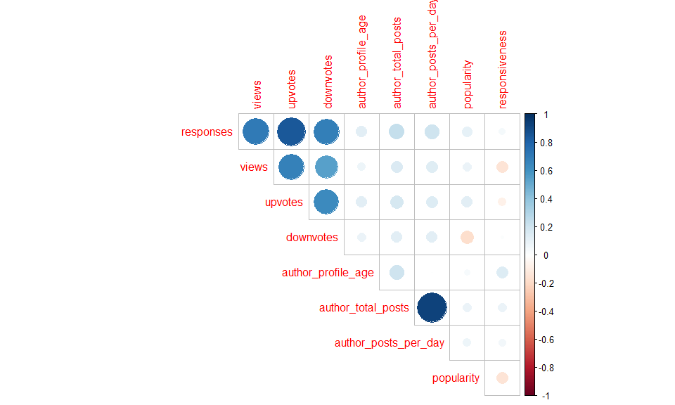

```r
correlations <- cor(subset(hrdata.train, select = -c(recommended)), use = "pairwise.complete.obs")
corrplot(correlations, diag = FALSE, type = "upper", tl.cex = 1)
```

The co-relation matrix confirms our initial assumption of data points being modelled after the real world.

## Section 4: Data Analysis/Modelling

This section is further more dividied into following subsection to guide our analysis.

1. Predictor selection - predictors that can classify suggestion
2. Modelling & Selection based on classification performance/CV

We drive both sections on with initial queries from our report assignment & purpose of modelling to draw conclusions.

### Predictor selection - predictors that can classify suggestion

We employ various predictor selection techniques to identify any predictors that can be used for our models.

#### Appearance of various predictors on regsubset model(s)

Following presents a sorted histogram of most frequent predictors picked by the regsubset model using exhaustive method accross various sizes of predictor picking.

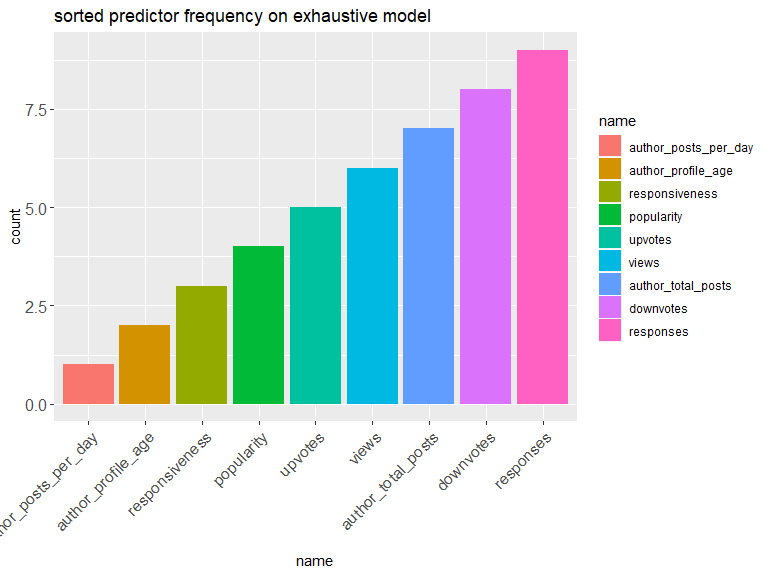

```r
predictor.analysis <- function(model) {
  hrdata.predictor.regsubsets <- sapply(as.data.frame(summary(model)$which), sum)
  hrdata.predictor.regsubsets <- hrdata.predictor.regsubsets[2:length(hrdata.predictor.regsubsets)]
  hrdata.predictor.regsubsets.df <- data.frame("name" = names(hrdata.predictor.regsubsets), "count" = hrdata.predictor.regsubsets)
  hrdata.predictor.regsubsets.df <- transform(hrdata.predictor.regsubsets.df, name = reorder(name, count))
  rownames(hrdata.predictor.regsubsets.df) <- NULL
  return(hrdata.predictor.regsubsets.df)
}

nvmax.size <- length(colnames(hrdata.train)) - 1

# Exhaustive
hrdata.exhaustive.model <- regsubsets(recommended ~ ., data = hrdata.train, nbest = 1, nvmax = nvmax.size,  method = "exhaustive", really.big = TRUE)
hrdata.exhaustive.model.analysis <- predictor.analysis(hrdata.exhaustive.model)
hrdata.exhaustive.model.plot <- ggplot(data = hrdata.exhaustive.model.analysis) + geom_bar(mapping = aes(x = name, y = count, fill = name),  position = "dodge", stat = "identity") + ggtitle("sorted predictor frequency on exhaustive model") + theme(axis.text.x = element_text(angle = 90, hjust = 1)) + theme(axis.text=element_text(size=12), axis.text.x = element_text(angle = 45, hjust = 1))

hrdata.exhaustive.model.plot
```

We can see that some predictors like respones, downvotes, viewes, author_total_posts & upvotes are consistently picked by the method and outperforms other predictors like responsiveness, author_posts_perday. & author_profile_age

#### Predictors selected by Lasso

We can get a rough estimate of if the predictors picked by regsubset are good estimater by checking if same predictors are picked by lasso. Below is the plot:

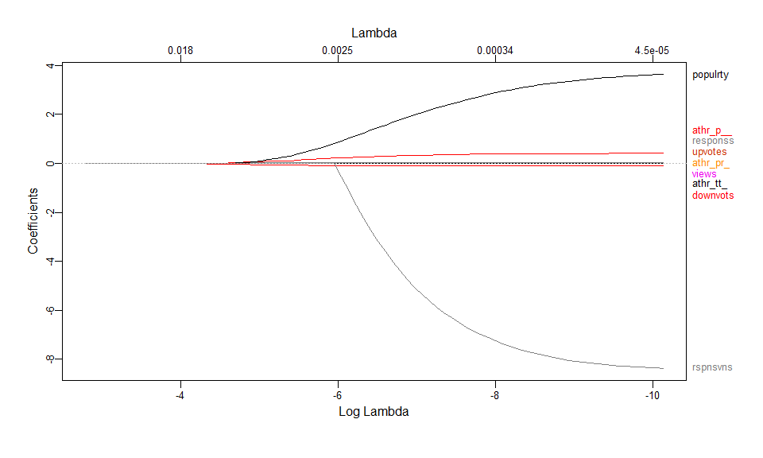

```r
# Extract response variable (for lasso)
hrdata.x <- as.matrix(hrdata.train[, -which(names(hrdata.train) == "recommended")])
hrdata.y <- hrdata.train$recommended
hrdata.lasso <- glmnet(data.matrix(hrdata.x), as.factor(hrdata.y), alpha=1, family="binomial")
plot_glmnet(hrdata.lasso)
```

#### Predictors selected by tree based method - random forest

Further confirming the predictors with default value of P at each split on random forest model:

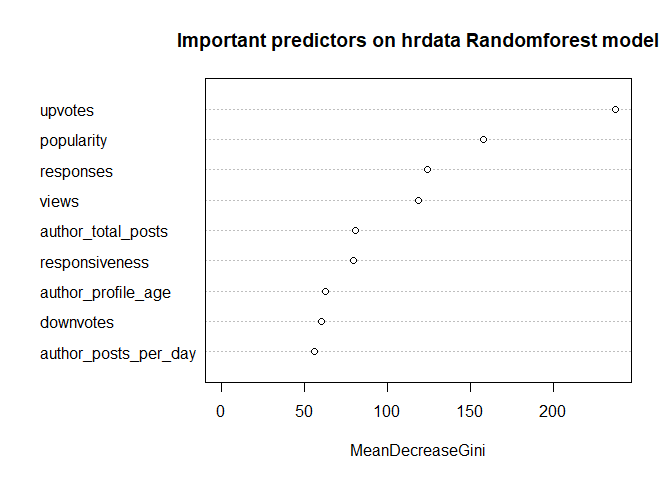

```r
#  Quick evaluation of random forest and most important variables
hrdata.rf <- randomForest(recommended ~ ., data = hrdata.train)
varImpPlot(hrdata.rf, main="Important predictors on hrdata Randomforest model", sort = T)
```

### Importance of “age” of employee profile for good prediction

###### Ref. ↓

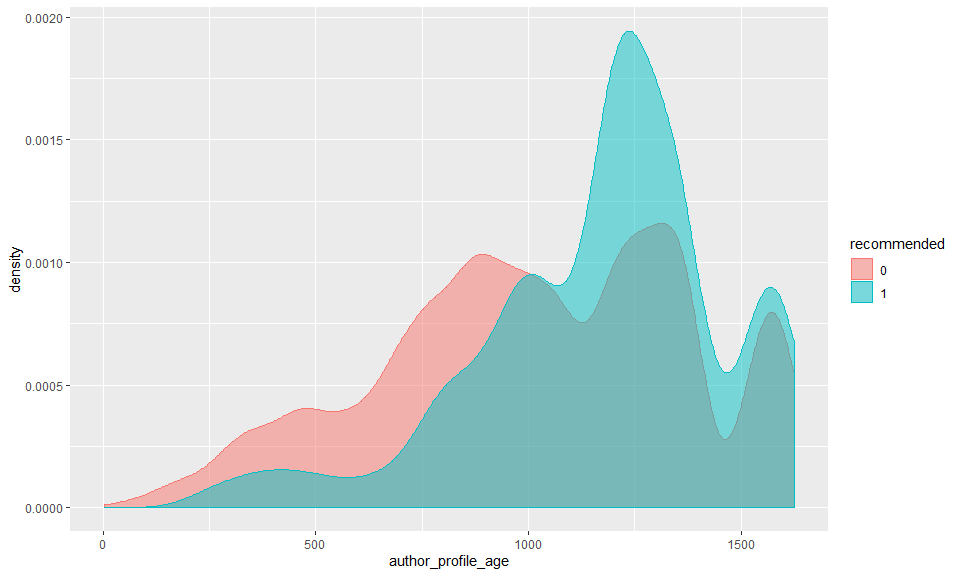

```r
densityplot.author_profile_age <- ggplot(hrdata, aes(x=author_profile_age, color=recommended, fill=recommended)) +   geom_density(alpha = 0.5)
densityplot.author_profile_age
```

###### Ref. ↓

We see from the density plot that while there is slightly higher distribution of good recommendations from profile with longer age. In earlier stages of profile making the recommendation the differences were proportional.

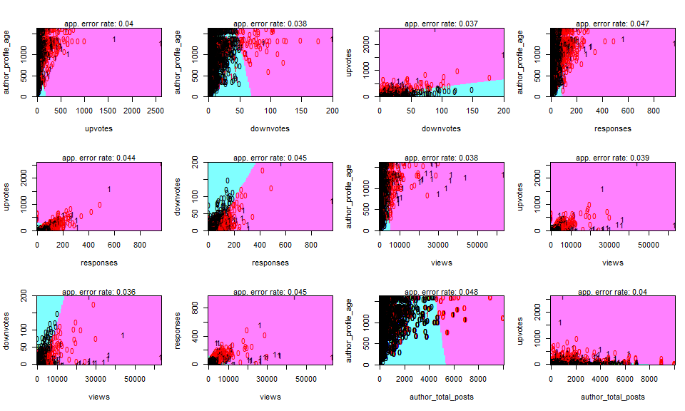

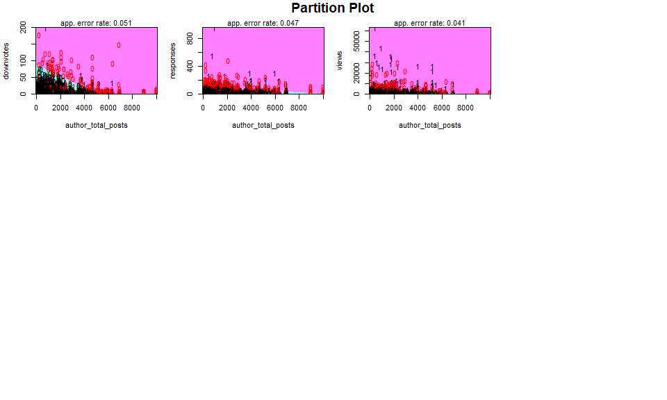

```r
partimat(recommended ~ author_profile_age + upvotes + downvotes + responses + views + author_total_posts, method="lda", data=hrdata.train)
```

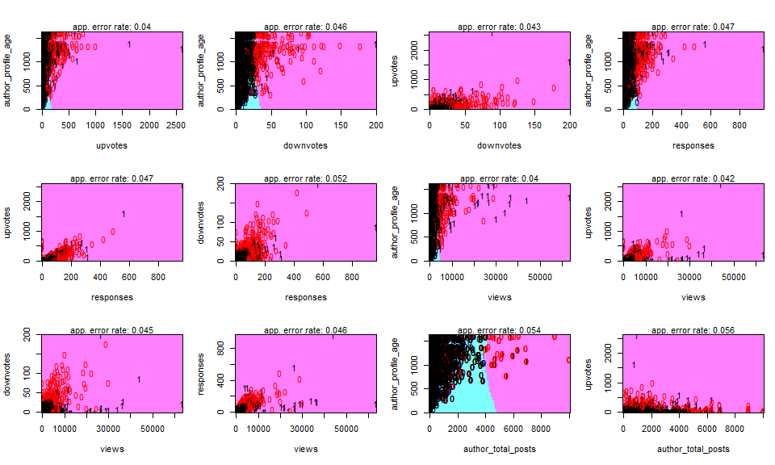

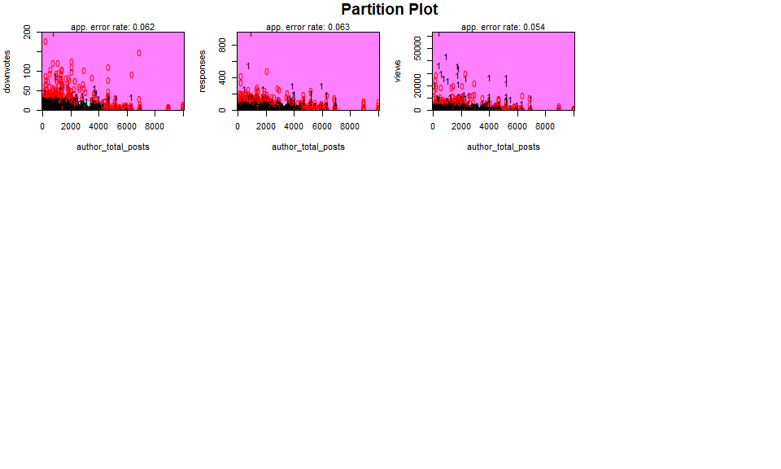

```r
partimat(recommended ~ author_profile_age + upvotes + downvotes + responses + views + author_total_posts, method="qda", data=hrdata.train)
```

First row on the above plot matrix shows error rates using LDA & QDA of author_profile_age against other predictors. The error rates for “age” seems comparable to author predictors.

Below provides scatter plot of the same using loess method.

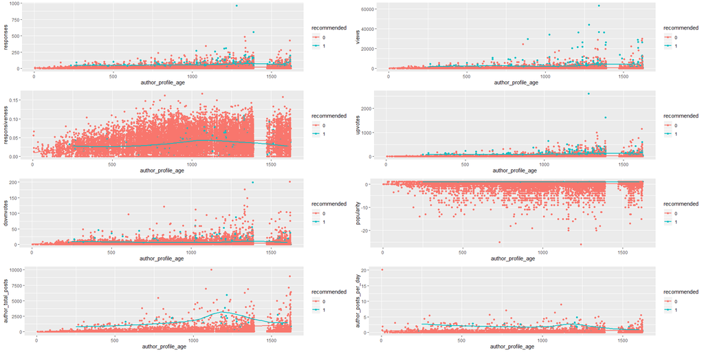

```r
hrdata.responses.glmplot <-  ggplot(hrdata, aes(x=author_profile_age, y=responses, color=recommended)) + geom_point() + geom_smooth(method=loess, se=FALSE, fullrange=TRUE)
hrdata.views.glmplot <- ggplot(hrdata, aes(x=author_profile_age, y=views, color=recommended)) + geom_point() + geom_smooth(method=loess, se=FALSE, fullrange=TRUE)
hrdata.responsiveness.glmplot <- ggplot(hrdata, aes(x=author_profile_age, y=responsiveness, color=recommended)) + geom_point() + geom_smooth(method=loess, se=FALSE, fullrange=TRUE)

hrdata.upvotes.glmplot <- ggplot(hrdata, aes(x=author_profile_age, y=upvotes, color=recommended)) + geom_point() + geom_smooth(method=loess, se=FALSE, fullrange=TRUE)
hrdata.downvotes.glmplot <- ggplot(hrdata, aes(x=author_profile_age, y=downvotes, color=recommended)) + geom_point() + geom_smooth(method=loess, se=FALSE, fullrange=TRUE)
hrdata.popularity.glmplot <- ggplot(hrdata, aes(x=author_profile_age, y=popularity, color=recommended)) + geom_point() + geom_smooth(method=loess, se=FALSE, fullrange=TRUE)

hrdata.author_total_posts.glmplot <- ggplot(hrdata, aes(x=author_profile_age, y=author_total_posts, color=recommended)) + geom_point() + geom_smooth(method=loess, se=FALSE, fullrange=TRUE)
hrdata.author_posts_per_day.glmplot <- ggplot(hrdata, aes(x=author_profile_age, y=author_posts_per_day, color=recommended)) + geom_point() + geom_smooth(method=loess, se=FALSE, fullrange=TRUE)

grid.arrange(hrdata.responses.glmplot,  hrdata.views.glmplot, hrdata.responsiveness.glmplot, hrdata.upvotes.glmplot, hrdata.downvotes.glmplot, hrdata.popularity.glmplot, hrdata.author_total_posts.glmplot, hrdata.author_posts_per_day.glmplot, ncol=2)
```

### Identification/Prediction of employees qualitiy who make “good” suggestions

Following subsection specifically aims to answer quality of subset of employees who do make good recommendations over others.

We start by creating a grouped set of our dataset grouped by author_id.

```r
### Group Training set

hrdata.train.group.author.rec <- hrdata.train.all %>% group_by(author_id) %>% summarise(recommended = sum(as.numeric(recommended)), views = mean(views), upvotes = mean(upvotes),  downvotes = mean(downvotes), responses = mean(responses), author_profile_age = max(author_profile_age), author_total_posts = max(author_total_posts), author_posts_per_day = max(author_posts_per_day), popularity = mean(popularity),responsiveness = mean(responsiveness))
hrdata.train.group.author.rec$success_rate = hrdata.train.group.author.rec$recommended/hrdata.train.group.author.rec$author_total_posts
```

Following shows how the total posts author has made compares against how frequently they are recommended. It’s not linear suggesting there are indeed some underlying qualities other dimensions have for frequency of recommendation besides just post.

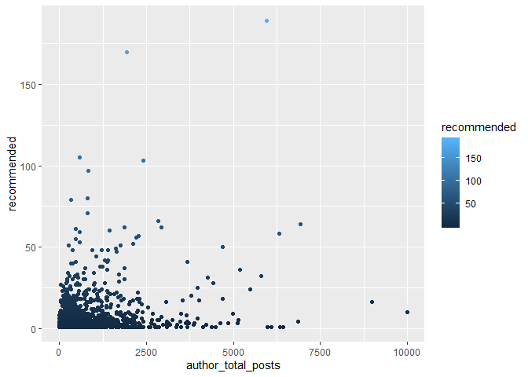

```r
ggplot(hrdata.train.group.author.rec, aes(x=author_total_posts, y=recommended, color=recommended)) + geom_point()
```

###### Ref. ↓

We perform repeated regsubset against these grouped data set to identify on predictors using sucess_rate & total # of recommendation made by that author as the response variable to see what predictors are trending upwards which we will use to infer conclusions about quality of author who get more recommendations.

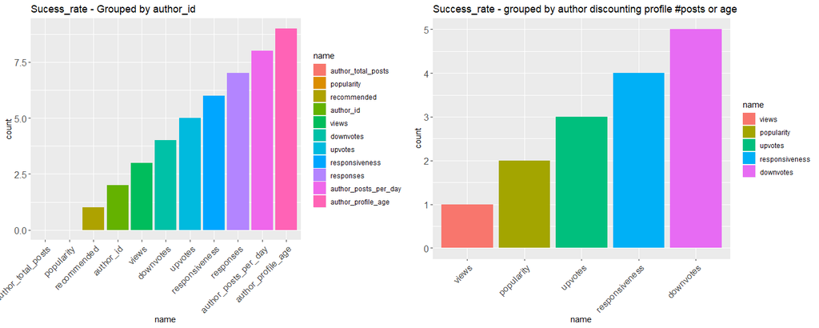

```r
# success_rate
hrdata.grouped.exhaustive.model <- regsubsets(success_rate ~ ., data = hrdata.train.group.author.rec, nbest = 1, nvmax = nvmax.size,  method = "exhaustive", really.big = TRUE)
hrdata.grouped.exhaustive.model.analysis <- predictor.analysis(hrdata.grouped.exhaustive.model)
hrdata.exhaustive.model.plot <- ggplot(data = hrdata.grouped.exhaustive.model.analysis) + geom_bar(mapping = aes(x = name, y = count, fill = name),  position = "dodge", stat = "identity") + ggtitle("Sucess_rate - Grouped by author_id") + theme(axis.text.x = element_text(angle = 90, hjust = 1)) + theme(axis.text=element_text(size=12), axis.text.x = element_text(angle = 45, hjust = 1))

# Sucess_rate without author_profile_age & author_posts_per_day

hrdata.groupedrec.exhaustive.model <- regsubsets(success_rate ~ popularity + views + downvotes + upvotes + responsiveness, data = hrdata.train.group.author.rec, nbest = 1, nvmax = nvmax.size,  method = "exhaustive", really.big = TRUE)
hrdata.groupedrec.exhaustive.model.analysis <- predictor.analysis(hrdata.groupedrec.exhaustive.model)
hrdata.exhaustive.rec.model.plot <- ggplot(data = hrdata.groupedrec.exhaustive.model.analysis) + geom_bar(mapping = aes(x = name, y = count, fill = name),  position = "dodge", stat = "identity") + ggtitle("Success_rate - grouped by author discounting profile #posts or age") + theme(axis.text.x = element_text(angle = 90, hjust = 1)) + theme(axis.text=element_text(size=12), axis.text.x = element_text(angle = 45, hjust = 1))


grid.arrange(hrdata.exhaustive.model.plot, hrdata.exhaustive.rec.model.plot, ncol = 2)
```

When grouped by author, it looks like the frequency of author definitely comes into play. Besides that we see response & upvotes become a factor for a sucess of author’s.

Having an older profile, mkaing more posts with upvotes & higher responses are likely to get recommended which falls in line with expectations.